# Authors: Gerard Mendoza, Matthew Muranaka

This model trains a random forest on all the data first since we got good results for class 2, then it separates class not 2 results and refines it through another random forest classification.

```python
logging.info("Making predictions with the initial model...")

# Create copies for safe experimentation
X_train_copy = np.copy(X_train_not_class_2)
X_test_copy = np.copy(X_test_not_class_2)
y_train_copy = np.copy(y_train_not_class_2)
y_test_copy = np.copy(y_test_not_class_2)
y_pred_all_copy = np.copy(y_pred_all)

logging.info("Training Random Forest for Class 1 vs Class 3...")
# Train a separate Random Forest for Class 1 vs Class 3
rf_not_class_2 = RandomForestClassifier(
    n_estimators=300,
    max_depth=15,
    min_samples_leaf=5,
    class_weight="balanced_subsample",
    random_state=11,
)
rf_not_class_2.fit(X_train_copy, y_train_copy)
y_pred_not_class_2 = rf_not_class_2.predict(X_test_copy)
final_predictions[not_class_2_indices] = y_pred_not_class_2

logging.info("Evaluating final model performance on all data...")
final_accuracy = accuracy_score(y_test, final_predictions)
final_conf_matrix = confusion_matrix(y_test, final_predictions)
final_classification_report = classification_report(y_test, final_predictions)
logging.info("Final Model Accuracy: %.4f", final_accuracy)
logging.info("Final Confusion Matrix:\n%s", final_conf_matrix)
logging.info("Final Classification Report:\n%s", final_classification_report)

subset_accuracy = accuracy_score(y_test_copy, y_pred_not_class_2)
subset_conf_matrix = confusion_matrix(y_test_copy, y_pred_not_class_2)
subset_classification_report = classification_report(y_test_copy, y_pred_not_class_2)
logging.info("Subset Accuracy (Class 1 vs 3): %.4f", subset_accuracy)
logging.info("Subset Confusion Matrix:\n%s", subset_conf_matrix)
logging.info("Subset Classification Report:\n%s", subset_classification_report)
logging.info("Hybrid Random Forest process completed.")
```

```
2024-11-30 21:24:26,049 - Making predictions with the initial model...
2024-11-30 21:24:26,107 - Training Random Forest for Class 1 vs Class 3...
2024-11-30 21:32:24,995 - Evaluating final model performance on all data...
2024-11-30 21:32:25,173 - Final Model Accuracy: 0.7247
2024-11-30 21:32:25,174 - Final Confusion Matrix:
[[ 30310      0  24228]
 [     0 134761      0]
 [ 29891  44989  95821]]
2024-11-30 21:32:25,174 - Final Classification Report:
              precision    recall  f1-score   support

           1       0.50      0.56      0.53     54538
           2       0.75      1.00      0.86    134761
           3       0.80      0.56      0.66    170701

    accuracy                           0.72    360000
   macro avg       0.68      0.71      0.68    360000
weighted avg       0.74      0.72      0.71    360000

2024-11-30 21:32:25,270 - Subset Accuracy (Class 1 vs 3): 0.6998
2024-11-30 21:32:25,270 - Subset Confusion Matrix:
[[30310 24228]
 [29891 95821]]
2024-11-30 21:32:25,271 - Subset Classification Report:
              precision    recall  f1-score   support

           1       0.50      0.56      0.53     54538
           3       0.80      0.76      0.78    125712

    accuracy                           0.70    180250
   macro avg       0.65      0.66      0.65    180250
weighted avg       0.71      0.70      0.70    180250

2024-11-30 21:32:25,271 - Hybrid Random Forest process completed.
```

This test has shown potential but we can improve on how we set up the model still. We want to keep working on doing the double random forest so the next experiment involves finding the most optimal settings for the model. We try a full grid search and apply a 3 fold cross validation test on it - this would mean 243 combinations of tests made 3 times each and estimated to take 50 hours. Grid search would help us systematically tune our model's hyperparameters to improve performance by automating the search process. It could also maybe reduce our overfitting but these are all just words, lets see how we did:

```python
import logging
from sklearn.model_selection import GridSearchCV
from sklearn.ensemble import RandomForestClassifier
from time import time

# Set up logging
logging.basicConfig(level=logging.INFO, format='%(asctime)s - %(message)s')
logger = logging.getLogger()

# Define parameter grid
param_grid = {
    'n_estimators': [100, 300, 500],
    'max_depth': [10, 15, 20],
    'min_samples_split': [2, 5, 10],
    'min_samples_leaf': [1, 5, 10],
    'max_features': ['sqrt', 'log2', None]
}

# Calculate total fits
total_combinations = (
    len(param_grid['n_estimators']) *
    len(param_grid['max_depth']) *
    len(param_grid['min_samples_split']) *
    len(param_grid['min_samples_leaf']) *
    len(param_grid['max_features'])
)
total_fits = total_combinations * 3  # 3 is the number of cross-validation folds

logger.info(f"Total parameter combinations: {total_combinations}")
logger.info(f"Total fits to perform (including CV): {total_fits}")

# Start timing
start_time = time()

# Set up Grid Search with verbose output
grid_search = GridSearchCV(
    RandomForestClassifier(random_state=11, class_weight="balanced_subsample"),
    param_grid,
    cv=3,
    scoring='f1_weighted',
    n_jobs=-1,
    verbose=3  # This will log progress of fits
)

logger.info("Starting Grid Search...")
grid_search.fit(X_train_not_class_2, y_train_not_class_2)
logger.info("Grid Search complete.")

# Best parameters and model
best_rf = grid_search.best_estimator_
logger.info("Best Parameters: %s", grid_search.best_params_)

# End timing
end_time = time()
logger.info("Total time for Grid Search: %.2f seconds", end_time - start_time)
```

```
2024-11-29 00:36:07,181 - Total parameter combinations: 243
2024-11-29 00:36:07,185 - Total fits to perform (including CV): 729
2024-11-29 00:36:07,189 - Starting Grid Search...
```

```
Fitting 3 folds for each of 243 candidates, totalling 729 fits
[CV 2/3] END max_depth=10, max_features=sqrt, min_samples_leaf=1, min_samples_split=2, n_estimators=300;, score=0.764 total time=10.9min
[CV 2/3] END max_depth=10, max_features=sqrt, min_samples_leaf=1, min_samples_split=5, n_estimators=500;, score=0.764 total time=17.3min
[CV 3/3] END max_depth=10, max_features=sqrt, min_samples_leaf=1, min_samples_split=10, n_estimators=500;, score=0.765 total time=17.2min
[CV 2/3] END max_depth=10, max_features=sqrt, min_samples_leaf=5, min_samples_split=5, n_estimators=500;, score=0.764 total time=28.4min
[CV 3/3] END max_depth=10, max_features=sqrt, min_samples_leaf=5, min_samples_split=10, n_estimators=500;, score=0.765 total time=255.0min
[CV 3/3] END max_depth=10, max_features=sqrt, min_samples_leaf=10, min_samples_split=5, n_estimators=300;, score=0.765 total time= 9.1min
[CV 2/3] END max_depth=10, max_features=sqrt, min_samples_leaf=10, min_samples_split=10, n_estimators=300;, score=0.764 total time=10.0min
[CV 2/3] END max_depth=10, max_features=log2, min_samples_leaf=1, min_samples_split=2, n_estimators=100;, score=0.764 total time= 3.5min
[CV 3/3] END max_depth=10, max_features=log2, min_samples_leaf=1, min_samples_split=2, n_estimators=300;, score=0.765 total time=11.5min
[CV 2/3] END max_depth=10, max_features=log2, min_samples_leaf=1, min_samples_split=5, n_estimators=300;, score=0.764 total time=11.7min
[CV 3/3] END max_depth=10, max_features=log2, min_samples_leaf=1, min_samples_split=10, n_estimators=100;, score=0.765 total time= 3.9min
[CV 2/3] END max_depth=10, max_features=log2, min_samples_leaf=1, min_samples_split=10, n_estimators=500;, score=0.764 total time=19.4min
[CV 1/3] END max_depth=10, max_features=log2, min_samples_leaf=5, min_samples_split=5, n_estimators=100;, score=0.765 total time= 3.9min
[CV 1/3] END max_depth=10, max_features=log2, min_samples_leaf=5, min_samples_split=5, n_estimators=300;, score=0.765 total time=11.6min
[CV 2/3] END max_depth=10, max_features=log2, min_samples_leaf=5, min_samples_split=10, n_estimators=100;, score=0.764 total time= 3.8min
[CV 3/3] END max_depth=10, max_features=log2, min_samples_leaf=5, min_samples_split=10, n_estimators=300;, score=0.765 total time=11.4min
[CV 2/3] END max_depth=10, max_features=log2, min_samples_leaf=10, min_samples_split=2, n_estimators=300;, score=0.764 total time=11.3min
[CV 3/3] END max_depth=10, max_features=log2, min_samples_leaf=10, min_samples_split=5, n_estimators=100;, score=0.765 total time= 3.7min
[CV 2/3] END max_depth=10, max_features=log2, min_samples_leaf=10, min_samples_split=5, n_estimators=500;, score=0.764 total time=18.8min
[CV 1/3] END max_depth=10, max_features=None, min_samples_leaf=1, min_samples_split=2, n_estimators=100;, score=0.765 total time=11.3min
[CV 1/3] END max_depth=10, max_features=None, min_samples_leaf=1, min_samples_split=2, n_estimators=500;, score=0.765 total time=56.1min
[CV 1/3] END max_depth=10, max_features=None, min_samples_leaf=1, min_samples_split=10, n_estimators=100;, score=0.765 total time=11.3min
[CV 3/3] END max_depth=10, max_features=None, min_samples_leaf=1, min_samples_split=10, n_estimators=300;, score=0.765 total time=33.7min
[CV 1/3] END max_depth=10, max_features=None, min_samples_leaf=5, min_samples_split=2, n_estimators=300;, score=0.765 total time=31.9min
[CV 2/3] END max_depth=10, max_features=None, min_samples_leaf=5, min_samples_split=5, n_estimators=100;, score=0.764 total time=10.0min
[CV 1/3] END max_depth=10, max_features=None, min_samples_leaf=5, min_samples_split=5, n_estimators=500;, score=0.765 total time=59.2min
[CV 3/3] END max_depth=10, max_features=None, min_samples_leaf=5, min_samples_split=10, n_estimators=500;, score=0.765 total time=174.6min
[CV 1/3] END max_depth=10, max_features=None, min_samples_leaf=10, min_samples_split=5, n_estimators=500;, score=0.765 total time=102.8min
[CV 3/3] END max_depth=10, max_features=None, min_samples_leaf=10, min_samples_split=10, n_estimators=500;, score=0.765 total time=71.2min
[CV 3/3] END max_depth=15, max_features=sqrt, min_samples_leaf=1, min_samples_split=10, n_estimators=300;, score=0.765 total time=16.7min
[CV 3/3] END max_depth=15, max_features=sqrt, min_samples_leaf=5, min_samples_split=2, n_estimators=300;, score=0.765 total time=17.3min
[CV 1/3] END max_depth=15, max_features=sqrt, min_samples_leaf=5, min_samples_split=5, n_estimators=300;, score=0.765 total time=20.4min
[CV 2/3] END max_depth=15, max_features=sqrt, min_samples_leaf=5, min_samples_split=10, n_estimators=100;, score=0.764 total time= 4.5min
[CV 3/3] END max_depth=15, max_features=sqrt, min_samples_leaf=5, min_samples_split=10, n_estimators=300;, score=0.765 total time=14.0min
[CV 2/3] END max_depth=15, max_features=sqrt, min_samples_leaf=10, min_samples_split=2, n_estimators=300;, score=0.764 total time=29.5min
[CV 3/3] END max_depth=15, max_features=sqrt, min_samples_leaf=10, min_samples_split=5, n_estimators=100;, score=0.765 total time= 4.3min
[CV 2/3] END max_depth=15, max_features=sqrt, min_samples_leaf=10, min_samples_split=5, n_estimators=500;, score=0.764 total time=22.1min
[CV 1/3] END max_depth=15, max_features=log2, min_samples_leaf=1, min_samples_split=2, n_estimators=100;, score=0.765 total time= 4.6min
[CV 1/3] END max_depth=15, max_features=log2, min_samples_leaf=1, min_samples_split=2, n_estimators=300;, score=0.765 total time=15.9min
```

[output cut: 20 more lines]

[output not shown]

[output cut: 94 more lines]

## Applied Principal Component Analysis

We first obtain the top 2 principal components and train the optimized random forest model produced by the grid search to the singular, multinomial classification task.

```python
df_tot = copy.copy(df_scaled)
X = df_tot.drop(columns=['Class'])
y = df_tot['Class']
X_train, X_test, y_train, y_test = train_test_split(X, y, test_size=0.2, random_state=3)

# perform principal component analysis for n_components=2
pca = PCA(n_components=2)
X_train = pca.fit_transform(X_train)
y_train = y_train.to_numpy()

# fit and test
rfc = RandomForestClassifier(
    n_estimators=100,          # Optimal from Grid Search
    max_depth=10,              # Optimal from Grid Search
    min_samples_split=2,       # Optimal from Grid Search
    min_samples_leaf=1,        # Optimal from Grid Search
    max_features='log2',       # Optimal from Grid Search
    class_weight="balanced",
    random_state=11,
)
rfc.fit(X_train, y_train)

X_test = pca.transform(X_test)
y_pred = rfc.predict(X_test)
print(confusion_matrix(y_test, y_pred))
print(accuracy_score(y_test, y_pred))
```

```
[[19991     0 15926]
 [    0 90102     0]
 [19960 30000 64021]]
0.725475
```

While PCA is not necessarily needed here, I thought it would provide a valuable evulation metric that can later be seen in the Model Evaluation section.

Further, we applied the hierarchical classification technique for Class 2 and not Class 2 and applied the optimal random forest parameters found by the grid search.

```python
from sklearn.decomposition import PCA


# Log the start of the process
logging.info("Applying PCA to Not Class 2 training and testing sets...")

# Create copies for safe experimentation
X_train_copy = np.copy(X_train_not_class_2)
X_test_copy = np.copy(X_test_not_class_2)
y_train_copy = np.copy(y_train_not_class_2)
y_test_copy = np.copy(y_test_not_class_2)
y_pred_all_copy = np.copy(y_pred_all)


# Apply PCA
pca = PCA(n_components=2)
X_train_pca = pca.fit_transform(X_train_copy)
X_test_pca = pca.transform(X_test_copy)

# Log explained variance
explained_variance = pca.explained_variance_ratio_
logging.info("PCA Explained Variance Ratios: %s", explained_variance)
logging.info("Training Random Forest for Class 1 vs Class 3 with PCA-transformed data...")
rf_not_class_2 = RandomForestClassifier(
    n_estimators=100,          # Optimal from Grid Search
    max_depth=10,              # Optimal from Grid Search
    min_samples_split=2,       # Optimal from Grid Search
    min_samples_leaf=1,        # Optimal from Grid Search
    max_features='log2',       # Optimal from Grid Search
    class_weight="balanced",
    random_state=11,
)

rf_not_class_2.fit(X_train_pca, y_train_copy)
y_pred_not_class_2 = rf_not_class_2.predict(X_test_pca)
final_predictions[not_class_2_indices] = y_pred_not_class_2

logging.info("Evaluating final model performance on all data...")
final_accuracy = accuracy_score(y_test, final_predictions)
final_conf_matrix = confusion_matrix(y_test, final_predictions)
final_classification_report = classification_report(y_test, final_predictions)

logging.info("Final Model Accuracy: %.4f", final_accuracy)
logging.info("Final Confusion Matrix:\n%s", final_conf_matrix)
logging.info("Final Classification Report:\n%s", final_classification_report)
logging.info("Evaluating performance on Class 1 vs Class 3 subset...")
subset_accuracy = accuracy_score(y_test_copy, y_pred_not_class_2)
subset_conf_matrix = confusion_matrix(y_test_copy, y_pred_not_class_2)
subset_classification_report = classification_report(y_test_copy, y_pred_not_class_2)

logging.info("Subset Accuracy (Class 1 vs 3): %.4f", subset_accuracy)
logging.info("Subset Confusion Matrix:\n%s", subset_conf_matrix)
logging.info("Subset Classification Report:\n%s", subset_classification_report)
logging.info("PCA-based Random Forest process completed.")
```

[output not shown]

The model barely moves to our dissappointment. This made us suspicious on how this could be...

## Removing Eucliden Similar Observations

With the optimal random forest parameters, we explore the abilities of removing vectors that are close together in euclidean distance but differ in class label. The idea behind this model is to remove hypothetical noise from wrongly labelled or improper observations.

Note drop_indices are the indices of observations less than 0.05 euclidean distance from each other that have different class labels.

```python
# Drop indices and reset index
X_train = X_train.drop(index=drop_indices)
y_train = y_train.drop(index=drop_indices)

rfc = RandomForestClassifier(
    n_estimators=100,          # Optimal from Grid Search
    max_depth=10,              # Optimal from Grid Search
    min_samples_split=2,       # Optimal from Grid Search
    min_samples_leaf=1,        # Optimal from Grid Search
    max_features='log2',       # Optimal from Grid Search
    class_weight="balanced",
    random_state=11,
)
rfc.fit(X_train, y_train)

y_pred = rfc.predict(X_test)

print("Accuracy: ", accuracy_score(y_test, y_pred))
print("Confusion Matrix: \n", confusion_matrix(y_test, y_pred))
```

```
Accuracy:  0.7252542955326461
Confusion Matrix:
 [[ 97332      0  77872]
 [     0 436412      1]
 [ 96503 145428 310452]]
```

The results of the random forest classifier without the euclidean similar but different classes observations is about the same as the other results we have gotten.

# Model Validation

Most model validation was done alongside model training. You will notice the main evaluation metric used during model training was accuracy score which considers the percentage of predictions correctly labeled over the amount of test samples. Many of the models testing is accompanied with a confusion matrix. We decided to print confusion matrices because of its human readibility, allowing us to determine what type of missclassifications occurs during the testing process.

While certain models considered precision, recall, and f-score, we did not value these metrics as high as accuracy. The reason for this is the lack of knowledge about the dataset. Due to the unknown nature of the variables and class labels, we are unsure which classification label to value most. Consider the cost of false of Class 3 labels to be much higher than that of Class 1 or 2. If this was the case, we would regard precision or f-score as crucial metrics to consider when fitting a model. A similar situation can be said about recall and its high value for false negatives, and many other metrics which aim to evaluate the different rows/columns of the confusion matrix.

```python
df_tot = copy.copy(df_scaled)
X = df_tot.drop(columns=['Class'])
y = df_tot['Class']
X_train, X_test, y_train, y_test = train_test_split(X, y, test_size=0.2, random_state=52)

rfc = RandomForestClassifier(n_estimators=100, random_state=11)
rfc.fit(X_train, y_train)
y_pred = rfc.predict(X_test)

print("Accuracy: ", accuracy_score(y_test, y_pred))
print("Confusion Matrix: \n", confusion_matrix(y_test, y_pred))
```

```
Accuracy:  0.7254583333333333
Confusion Matrix:
 [[11075     0 24902]
 [    0 90124     7]
 [10765 30216 72911]]
```

Below is the random forest classifier with applied principal component analysis mentioned earlier. The real reason for this model is that it allows us to visualize missclassification in a two-dimensional space opposed to the 15-dimensional model above.

```python
df_tot = copy.copy(df_scaled)
X = df_tot.drop(columns=['Class'])
y = df_tot['Class']
X_train, X_test, y_train, y_test = train_test_split(X, y, test_size=0.2, random_state=3)

# perform principal component analysis for n_components=2
pca = PCA(n_components=2)
X_train = pca.fit_transform(X_train)
y_train = y_train.to_numpy()

# fit and test
rfc = RandomForestClassifier(
    n_estimators=100,          # Optimal from Grid Search
    max_depth=10,              # Optimal from Grid Search
    min_samples_split=2,       # Optimal from Grid Search
    min_samples_leaf=1,        # Optimal from Grid Search
    max_features='log2',       # Optimal from Grid Search
    class_weight="balanced",
    random_state=11,
)
rfc.fit(X_train, y_train)

X_test = pca.transform(X_test)
y_pred = rfc.predict(X_test)
print(confusion_matrix(y_test, y_pred))
print(accuracy_score(y_test, y_pred))
```

```
[[19991     0 15926]
 [    0 90102     0]
 [19960 30000 64021]]
0.725475
```

```python
print(type(X_test))
print(type(y_test))
```

```
<class 'numpy.ndarray'>
<class 'pandas.core.series.Series'>
```

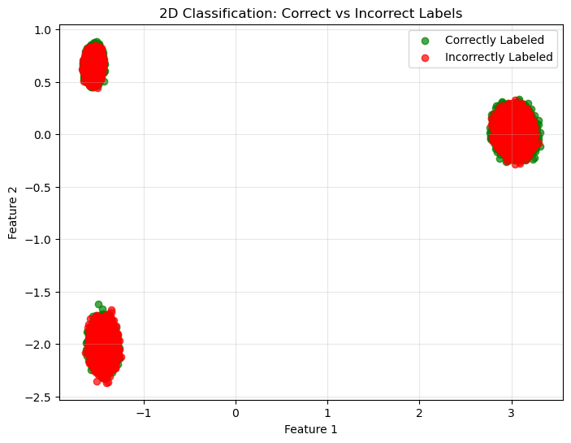

```python
correct_indices = np.where(y_test == y_pred)[0]
incorrect_indices = np.where(y_test != y_pred)[0]

# Plot the points
plt.figure(figsize=(8, 6))
plt.scatter(X_test[correct_indices, 0], X_test[correct_indices, 1], color='green', label='Correctly Labeled', alpha=0.7)
plt.scatter(X_test[incorrect_indices, 0], X_test[incorrect_indices, 1], color='red', label='Incorrectly Labeled', alpha=0.7)
plt.title("2D Classification: Correct vs Incorrect Labels")
plt.xlabel("Feature 1")
plt.ylabel("Feature 2")
plt.legend()
plt.grid(alpha=0.3)
plt.show()
```

You will notice the model is indifferent between the three clusters, these clusters are the same that were found in the Data Analysis portion. In order to gain a better insight into the performance between each cluster, we are going to perform KMeans clustering in order to determine which cluster each observation belongs to and evaluate each clusters performance using the optimized random forest model.

```python
from sklearn.cluster import KMeans

# train
cluster_amount = 3
km = KMeans(n_clusters=cluster_amount, random_state=10)
cluster_predict = km.fit_predict(X_test)
for i in range(cluster_amount):
    cluster_indices = np.where(cluster_predict == i)[0]
    X_test_cluster = X_test[cluster_indices]
    y_test_cluster = y_test.iloc[cluster_indices]

    y_pred_cluster = rfc.predict(X_test_cluster)
    print("Cluster", i)
    print(confusion_matrix(y_test_cluster, y_pred_cluster))
    print(accuracy_score(y_test_cluster, y_pred_cluster), "\n")
```

```
Cluster 0
[[    0 15926]
 [    4 64021]]
0.8007529611887281

Cluster 1
[[90102     0]
 [30000     0]]
0.7502123195284008

Cluster 2
[[19991     0]
 [19956     0]]
0.500438080456605
```

```python
print(km.cluster_centers_)
```

```
[[ 3.03762618  0.0223132 ]
 [-1.54504132  0.65831615]
 [-1.44343331 -2.01632125]]
```

Through this evaluation, we have determined the main issue with our classification stems from the accuracy of the bottom-most cluster where accuracy is about the same as randomly choosing between the two labels in that cluster. In comparison, the two top-most clusters produced accuracies above 75%.

Looking at the confusion matrix for each cluster it appears each cluster rarely or never predicts against the main label. In cluster 0, Class 3 is predicted in all but four of the observations. In cluster 1 and cluster 2, Class 2 and Class 1 is always predicted respectively.

In our model exploration, we attempted a couple of models including tree-based classifiers, KNN, and a nueral network with little success. Below is the neural network model with three hidden layers and the ReLU activation function.

```python
from sklearn.neural_network import MLPClassifier
km = KMeans(n_clusters=3, random_state=10)
cluster_predict = km.fit_predict(X_test)
cluster_indices = np.where(cluster_predict == 2)[0]

X_train_cluster = X_train[cluster_indices]
y_train_cluster = y_train[cluster_indices]
X_test_cluster = X_test[cluster_indices]
y_test_cluster = y_test.iloc[cluster_indices]


mlp = MLPClassifier(hidden_layer_sizes=(128, 64, 32))
mlp.fit(X_train_cluster, y_train_cluster)
y_pred_cluster = mlp.predict(X_test_cluster)
print("Cluster", 2)
print(confusion_matrix(y_test_cluster, y_pred_cluster))
print(accuracy_score(y_test_cluster, y_pred_cluster), "\n")
```

```
Cluster 2
[[19989     2]
 [19955     1]]
0.5004130472876561
```

[figure not shown]

```python
import matplotlib.pyplot as plt
import seaborn as sns

import matplotlib.pyplot as plt
import pandas as pd

# Extract feature importances from the Class 1 vs Class 3 model
importances = rf_not_class_2.feature_importances_
feature_names = [f"PC{i+1}" for i in range(len(importances))]
importance_df = pd.DataFrame({"Feature": feature_names, "Importance": importances})
importance_df = importance_df.sort_values(by="Importance", ascending=False)

# Plot feature importance
plt.figure(figsize=(10, 6))
plt.barh(importance_df["Feature"], importance_df["Importance"], color="skyblue")
plt.xlabel("Feature Importance")
plt.ylabel("Principal Components")
plt.title("Feature Importance for Class 1 vs Class 3")
plt.gca().invert_yaxis()
plt.show()
```

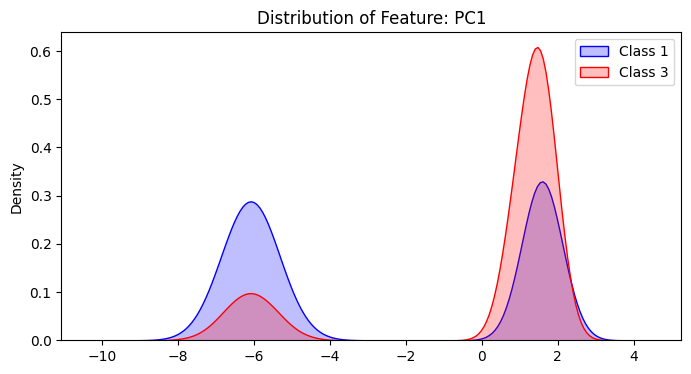

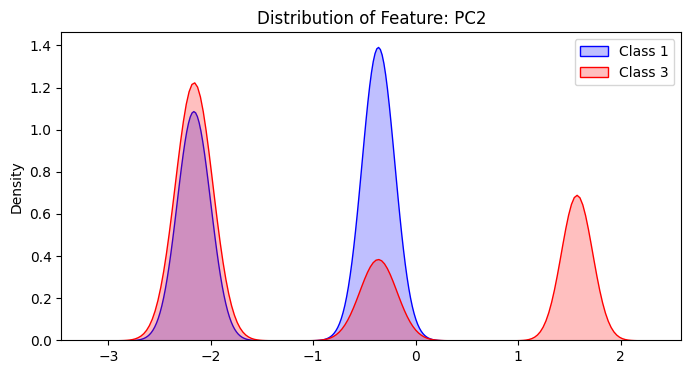

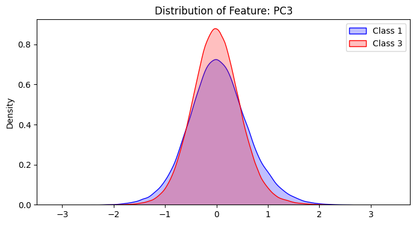

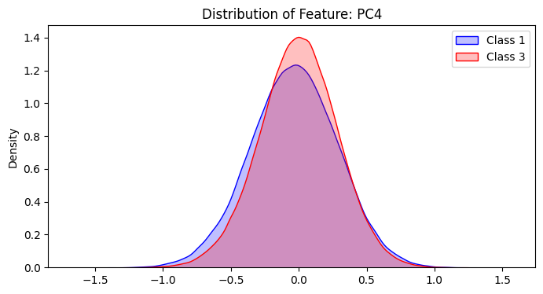

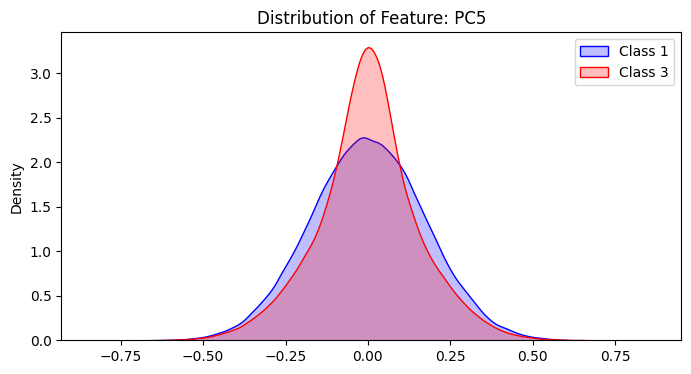

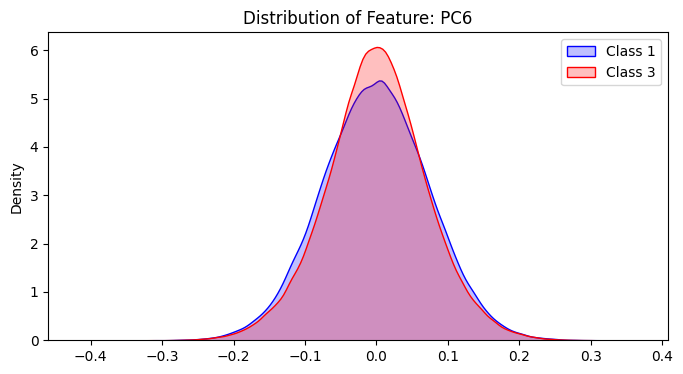

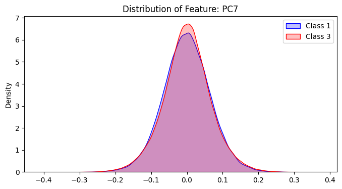

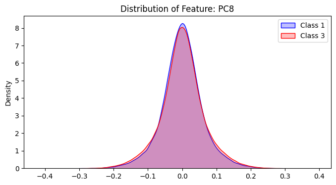

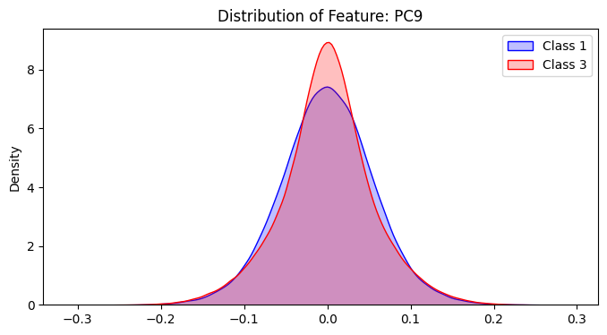

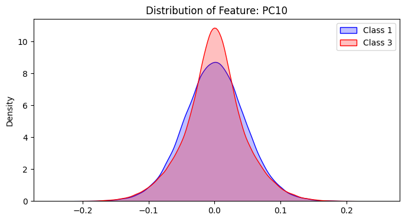

```python
class_1_data = X_train_not_class_2[y_train_not_class_2 == 1]
class_3_data = X_train_not_class_2[y_train_not_class_2 == 3]

# Plot feature distributions
for i, feature in enumerate(feature_names):
    plt.figure(figsize=(8, 4))
    sns.kdeplot(class_1_data[:, i], label='Class 1', shade=True, color='blue')
    sns.kdeplot(class_3_data[:, i], label='Class 3', shade=True, color='red')
    plt.title(f'Distribution of Feature: {feature}')
    plt.legend()
    plt.show()
```

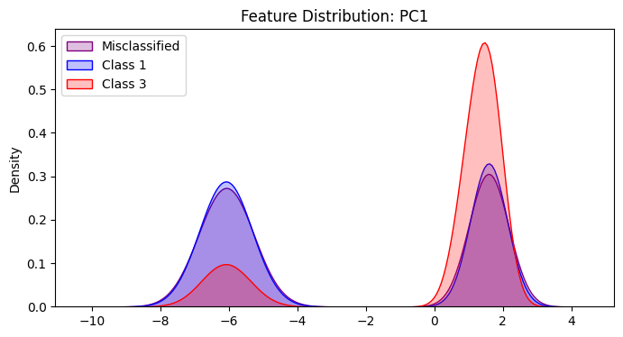

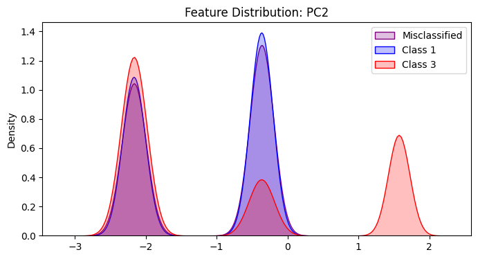

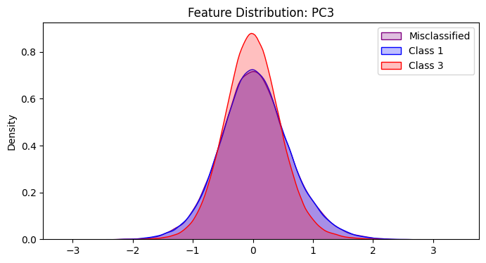

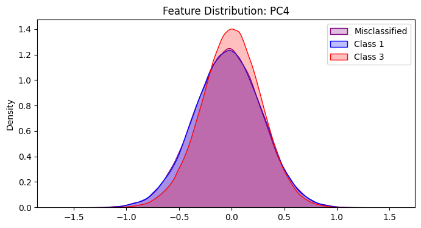

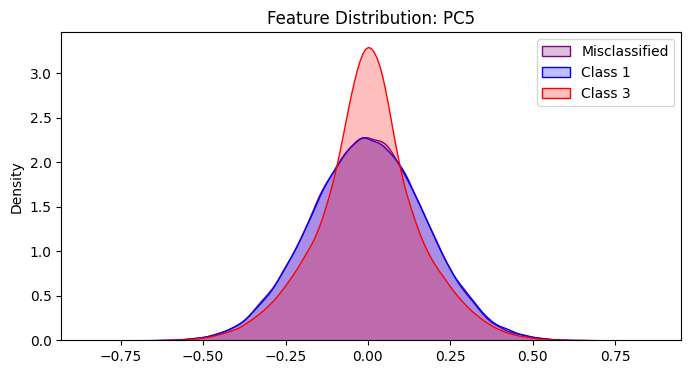

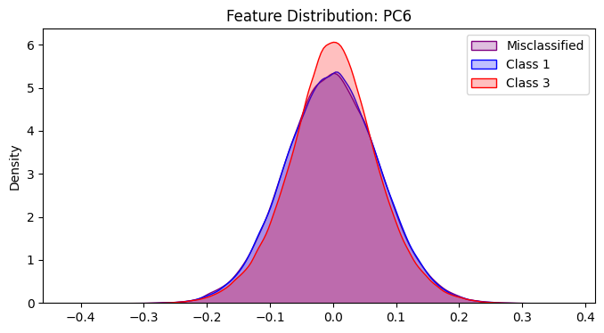

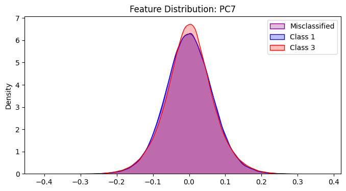

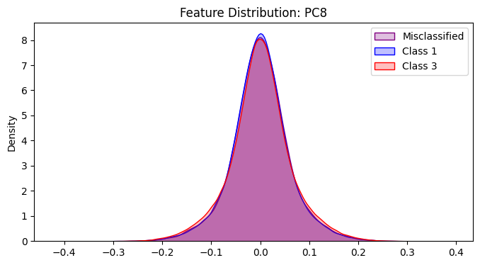

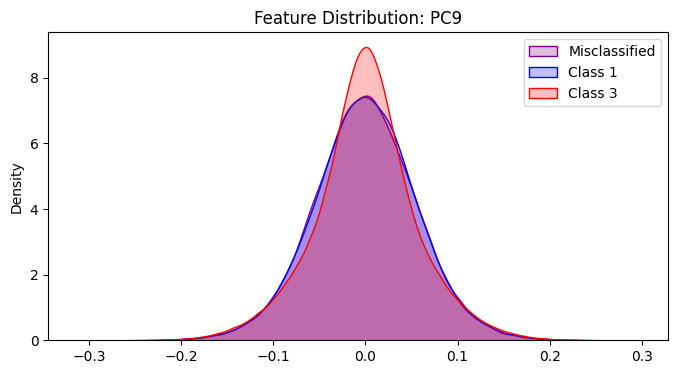

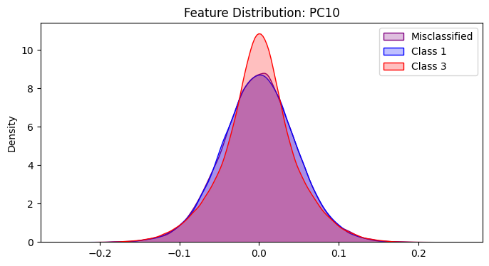

```python
# Identify misclassified samples
misclassified_indices = np.where(y_test_not_class_2 != y_pred_not_class_2)[0]
misclassified_data = X_test_not_class_2[misclassified_indices]
misclassified_labels = y_test_not_class_2[misclassified_indices]
misclassified_predictions = y_pred_not_class_2[misclassified_indices]

for i, feature in enumerate(feature_names):
    plt.figure(figsize=(8, 4))
    sns.kdeplot(misclassified_data[:, i], label='Misclassified', shade=True, color='purple')
    sns.kdeplot(class_1_data[:, i], label='Class 1', shade=True, color='blue')
    sns.kdeplot(class_3_data[:, i], label='Class 3', shade=True, color='red')
    plt.title(f'Feature Distribution: {feature}')
    plt.legend()
    plt.show()
```

And as you can see here, this was our attempt to visualize why it is so hard for us to seperate class 1 vs class 3. The most important features after pca comes from pc1 and pc2 - the rest of the pca through 10 has heavy overlap and would not be useful in figuring out discernable differences. Even with the two features identified, they have some overlap

# Conclusion

Overall, our models were able to maximize the classifications with the separable data through our different techniques of testing. We explored different models both linear and nonlinear while applying ways that can balance the data itself like PCA, SMOTE, and similarity analysis. Our models saw success in classifying certain labels while experiencing persistent struggles with identifying Class 3 labels. Class 2 had a high recall and f1 score leading us to focus more on what we really struggled with which was separating class 1 and 3. Our issues came from how consistent all our testing came to be. Despite changing up the models, tuning all the parameters, balancing the data, and hours of optimization we would be fixed around 72~73% accuracy. This made it hard to expand on ideas we had and constrained us on data visualization and understanding. Through all our graphs we saw most of our difficulties rest in how much overlap there was between class 1 and 3. A majority of the features had heavy overlap causing them to be redundant and the 2 features that were supposed to be the most important still had a good portion of overlap.

If we had another chance at classifying this dataset, we would attempt to model the data through a discretized process. The results of the cluster analysis and misclassification distribution indicate our models experienced difficulty with truly identifying between the classes. One possible way to improve results is splitting the problem into three separate problems, one for each distinct cluster, and repeating the process for each cluster of observations. While initial model exploration struggled with predicting within clusters, performing data analysis by cluster rather than the whole dataset may lead to performance improvements.

With knowledge of the data and the meaning of a sample’s class label, model performance could be optimized towards certain classes, maximizing situational metrics. Further, there would be a greater understanding of the data analysis and the results from features.

## Model Export

```python
from sklearn2pmml.decoration import ContinuousDomain
from sklearn2pmml.pipeline import PMMLPipeline
from sklearn2pmml import sklearn2pmml
from sklearn_pandas import DataFrameMapper

df_tot = copy.copy(df)
X = df_tot.drop(columns=['Class'])
y = df_tot['Class']
X_train, X_test, y_train, y_test = train_test_split(X, y, test_size=0.2, random_state=3)

pipeline = PMMLPipeline([
    ('mapper',
     DataFrameMapper([
         (X_train.columns.values,
          [ContinuousDomain(),
           MinMaxScaler()])])),
    ('classifier',
     RandomForestClassifier(
        n_estimators=100,
        max_depth=10,
        min_samples_split=2,
        min_samples_leaf=1,
        max_features='log2',
        class_weight="balanced",
        random_state=11,
    ))
])

pipeline.fit(df_tot.drop('Class', axis=1),
             df_tot['Class']);
```

```python
print(classification_report(pipeline.predict(X_test),
                            y_test))
```

```
              precision    recall  f1-score   support

           1       0.56      0.50      0.53     39948
           2       1.00      0.75      0.86    120102
           3       0.56      0.80      0.66     79950

    accuracy                           0.73    240000
   macro avg       0.71      0.68      0.68    240000
weighted avg       0.78      0.73      0.74    240000
```

```python
sklearn2pmml(pipeline,
             '/Users/matthewmuranaka/Documents/CSP571/project/project_pipeline.pmml',
             with_repr = True)
```

# Imports

Below contains relevant imports to the project process.

```python
import pandas as pd
import numpy as np
import copy
import time
import os
import random
import math

from sklearn.preprocessing import MinMaxScaler
from sklearn.model_selection import train_test_split
from sklearn.linear_model import LogisticRegression
from sklearn.decomposition import PCA
from sklearn.metrics import confusion_matrix
from sklearn.metrics import accuracy_score
from sklearn.ensemble import RandomForestClassifier
from sklearn.metrics import accuracy_score, confusion_matrix
from sklearn.metrics import classification_report

from scipy.spatial.distance import pdist, squareform

import matplotlib.pyplot as plt

import seaborn as sns

import warnings
warnings.filterwarnings('ignore')
```

# Data Sources

https://www.geeksforgeeks.org/how-to-count-occurrences-of-specific-value-in-pandas-column/  
https://stackoverflow.com/questions/68972590/minmaxscaler-vs-standardscaler-for-scaling-features  
https://stackoverflow.com/questions/17627219/whats-the-fastest-way-in-python-to-calculate-cosine-similarity-given-sparse-mat  
https://www.geeksforgeeks.org/machine-learning-model-evaluation/  
https://www.geeksforgeeks.org/metrics-for-machine-learning-model/  
https://medium.com/@fatmanurkutlu1/model-evaluation-techniques-in-machine-learning-8cd88deb8655  
https://medium.com/@jscvcds/a-step-by-step-guide-to-model-evaluation-in-python-3a72dee92560  
https://datatron.com/how-to-evaluate-your-machine-learning-models-with-python-code/  
https://www.analyticsvidhya.com/blog/2019/08/11-important-model-evaluation-error-metrics/  
https://www.jcchouinard.com/model-evaluation-in-machine-learning/  
https://www.comet.com/site/blog/introduction-to-machine-learning-model-evaluation/  
https://www.nobledesktop.com/learn/python/evaluating-model-performance-metrics-and-techniques  
https://towardsdatascience.com/good-approach-to-evaluate-your-machine-learning-model-e2e1fd6aa6bb

# Source Code

### SciKit Learn

https://scikit-learn.org/1.5/modules/preprocessing.html#  
https://scikit-learn.org/dev/modules/generated/sklearn.decomposition.PCA.html  
https://scikit-learn.org/1.5/modules/model_evaluation.html  
https://scikit-learn.org/1.5/modules/generated/sklearn.ensemble.RandomForestClassifier.html  
https://scikit-learn.org/dev/modules/generated/sklearn.ensemble.GradientBoostingClassifier.html  
https://scikit-learn.org/1.5/api/sklearn.neural_network.html  
https://scikit-learn.org/1.5/modules/generated/sklearn.cluster.KMeans.html

### Pandas

https://pandas.pydata.org/docs/reference/api/pandas.DataFrame.agg.html  
https://pandas.pydata.org/docs/reference/api/pandas.DataFrame.corr.html  
https://pandas.pydata.org/docs/reference/api/pandas.DataFrame.drop.html

### Seaborn

https://seaborn.pydata.org/generated/seaborn.heatmap.html  
https://seaborn.pydata.org/generated/seaborn.pairplot.html

### Other Help

https://chatgpt.com/

# Bibliography

<sup>1</sup> Nitesh, V. Chawla. "SMOTE: synthetic minority over‐sampling technique." J Artif Intell Res 16, no. 1 (2002): 321.  
<sup>2</sup> Gordon, Allan D. "A review of hierarchical classification." Journal of the Royal Statistical Society: Series A (General) 150, no. 2 (1987): 119-137.